# MSBMI 33200: Lecture 6

Anoop Mayampurath

November 11, 2019

```r
#set.seed(334)
#sample(seq(1, 8), 8, replace = FALSE)
# 6 5 7 8 2 1 4 3
```

Support vector machines (SVMs) work on the theory of maximizing the “gap” between classes. We build up to SVMs by first learning about

. Hyperplanes

. Maximal marginal classifer

. Support vector classifier

## Hyperplane

Definition: In a $p$-dimensional space, a hyperplane is a flat affine subspace of dimension $p-1$.

. when $p=2$, it is a line

. when $p=3$, it is a plane

. in a $p$ space, it is a $p-1$ dimensional flat subspace.

Consider a 2-D space with variables $X_{1}$ and $X_{2}$.

Mathematically, a hyperplane is defined by the equation

$$\beta_{0} + \beta_{1}X_{1} + \beta_{2}X_{2} = 0$$

Any value of $(X_{1}, X_{2})$ for which the above holds is a point on the hyperplane.

For a $p$-dimensional space

$$\beta_{0} + \beta_{1}X_{1} + \beta_{2}X_{2} + \dots + \beta_{p}X_{p} = 0$$

For all points that don’t satisfy the equality criterion, there are two options:

$$\beta_{0} + \beta_{1}X_{1} + \beta_{2}X_{2} + \dots + \beta_{p}X_{p} > 0$$
which means the point lies on one side of the hyperplane, and

$$\beta_{0} + \beta_{1}X_{1} + \beta_{2}X_{2} + \dots + \beta_{p}X_{p} < 0$$

which means the point lies on the other side of the hyperplane.

Thus, the hyperplane divides the space into two-halves.

Consider a binary dataset with two predictors ($X = [X_{1}, X_{2}]$). Let a single data point be noted as $x_{ij}$. Let the response be $Y$ and the class labels be (+1, -1)

What if we have a hyperplane that divides the space so that all points on side is one class and all points on the other side are the other class?

This is called “separating” hyperplane, and this forms the intuition behind SVMs.

A separating hyperplane would look like this:

$$\beta_{0} + \beta_{1}x_{i1} + \beta_{2}x_{i2} > 0 , y_{i} = 1$$

and

$$\beta_{0} + \beta_{1}x_{i1} + \beta_{2}x_{i2} < 0 , y_{i} = -1$$
where $i = 1 \dots n$, the number of observations

Cumulatively, the separating hyperplane has the property that

$$y_{i} (\beta_{0} + \beta_{1}x_{i1} + \beta_{2}x_{i2}) > 0$$

Let’s assume that such a hyperplane exits.

How do you use this for classification?

We take a test observation, and plug into the previous equations. The predicted label is +1 and -1 depending on whether the equation computes to >0 and <0.

Also, if the computed value is much greater (or lesser) than 0, then we can be more confident about our prediction than if it is around 0.

## Maximal Margin Classifier

If, in general, there is a possibility of linear seperation, then there are theoretically infinte separate hyperplanes.

We could choose the hyperplane that maximizes the distance to each of the training points. But that is an overkill.

The points closest to the plane are the most sensitive to the placement of the hyperplane. If they move, the hyperplane moves. Thus, focusing on these points should suffice.

Suppose we call the distance between the hyperplane and the nearest data point as the margin.

The maximal margin seeks to find the hyperplane that is furthest away from the nearest data point. In other words maximal margin classifier finds the hyperplane that maximizes the margin.

Our hope is that a hyperplane that has maximal margins on the training dataset will have maximal margins on the test dataset.

In the figure below (from https://idc9.github.io/stor390/), the training observation that are closest and equidistant to the hyperplane are called “support vectors”.

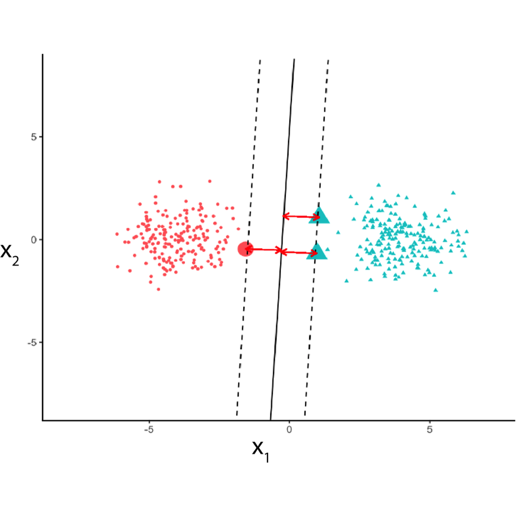

How do we build this?

We solve the following quadratic equation that seeks to maximize margin distance M.

$$\begin{equation*}
\begin{aligned}
& \underset{\beta_{0},\beta_{1}, \dots \beta_{p}}{\text{maximize}}
& & M \\
& \text{subject to}
& & \sum_{j=1}^{p} \beta_{j}^2 = 1 \\
&
& & y_{i} (\beta_{0} + \beta_{1}x_{i1} + \beta_{2}x_{i2}) \geq M \forall i = 1, \ldots, n
\end{aligned}
\end{equation*}$$

## Support vector classifer

If the class labels are not linearly separable (i.e. there is no separating hyerplane), the maximal margin classifier will not have a solution to the optimization problem.

It is also in our best interest to not assume linear separation, since this may lead to a classifer with a high variance. The addition of a single observation may skew the hyperplane dramatically.

It might be better to miss-classify a few data points in the training dataset to reduce the chances of overall error on the test dataset.

The objective of a support vector classifier (also called a soft margin classifier) is to choose the best seperating hyperplane that minimizes the miss-classification error.

In other words, rather than choosing the largest possible margin so that every observation of a given class lies on one side of the margin (or one side of the hyperplane), it allows for some observations to fall on the wrong side of the margin (or the hyperplane). The margin is thus denoted as being ‘soft’.

We build this by solving the following optimization problem

$$\begin{equation*}
\begin{aligned}
& \underset{\beta_{0},\beta_{1}, \dots \beta_{p},\epsilon_{0},\epsilon_{1}, \dots \epsilon_{n}}{\text{maximize}}
& & M \\
& \text{subject to}
& & \sum_{j=1}^{p} \beta_{j}^2 = 1 \\
&
& & y_{i} (\beta_{0} + \beta_{1}x_{i1} + \beta_{2}x_{i2}) \geq M(1-\epsilon_{i}), \\
&
& & \epsilon_{i} \geq 0, \\
&
& & \sum_{i=1}^{n} \epsilon_{i} \leq C
\end{aligned}
\end{equation*}$$

where - $M$ is the width of the margin  
- $\epsilon_{1}, \epsilon_{2}, \dots \epsilon_{p}$ are the allowable errors  
- $i = 1, 2 \dots n$ observations

If $\epsilon_{i}= 0$, then the $i^{th}$ observation is on the correct side of the margin.

If $\epsilon_{i}> 0$, then the $i^{th}$ observation is on the wrong side, which is allowed here. This is called as violation.

We control the number of total violations by the cost parameter $C$, usually chosen through cross-validation.

As the cost $C$ increases, we become more tolerant of violations to the margin, so the margin will widen (low variance). Conversely as $C$ decreases, we become less tolerant of allowing violations and the margin narrows (high variance).

From James et al. Introduction to Statistical Learning 2015

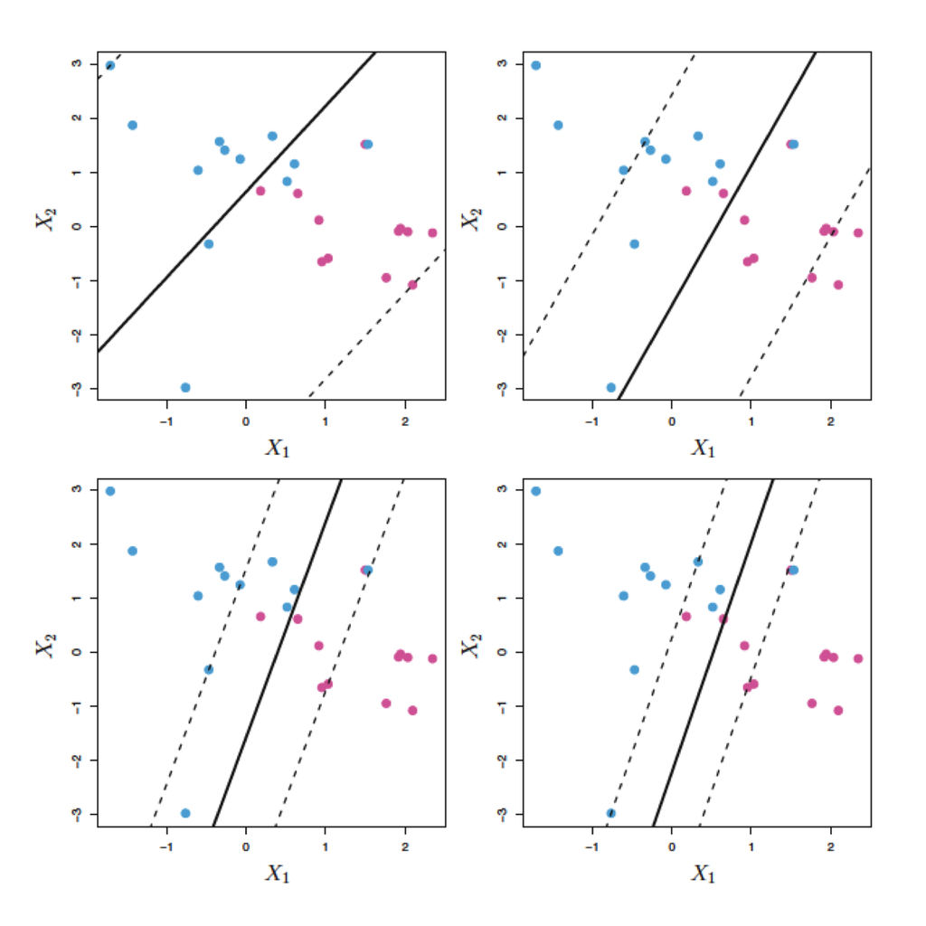

Now, the hyperplane is affected by two types of observations:

1. Observations that lie on the margin
2. Observations that are on the wrong side.

These are called support vectors.

## Support Vector Machines

Support Vector Machines extends upon the idea of support vector classifier by looking for non-linear class boundaries.

They do this by increasing the dimensions of the feature space (e.g. from $p$ to $p^2$) and then looking for a linear-class boundary.

The increase in dimensions is done through transformations called kernels

A kernel is a function that quantifies the similarity of two observations. Consider two observational points Below are a few examples

Polynomial Kernel of degree $d$

$$K(x_{i}, x_{i'}) = (1 + \sum_{j=1}^{p}x_{ij}x_{i'j})^d$$

Radial Kernel

$$K(x_{i}, x_{i'}) = exp (-\gamma \sum_{j=1}^{p}(x_{ij}-x_{i'j})^2)$$

Using the kernel functions, the optimization is now performed on a higher-dimensional space that captures similarity between the original observations.

Support vector classifiers where the dataset is transformed using non-linear kernels are called as support vector machines.

## Multi-class SVM

If we are dealing with K class labels,

- One-versus-one method: construct choose($K$,2) SVMs for each pair of classes. Classify the test observation using all SVMs and then count the number of times the test observation was assigned a particular class. Choose the majority vote as the final predicted class.
- One-versus-all method: construct $K$ SVMs that are trained specifically for each class versus rest of classes. Classify the test observation using all SVMs. Choose the predicted label that has maximal distance from the margin.